# Data Science Midterm Progress Report

Sam Goss

September 22, 2020

## Premature Engine Removals

### DATA

- I:"engineRemovals20172020.csv"
- Includes data on 2463 engine removals from Jan 2017 - Sep 2020
- CSV file of excel spreadsheet of removals maintained by Engine Planning Department
- Sample of Data

```r
head(eng_rems)
```

```
## # A tibble: 6 x 18
##      MM Mon   Date  `Engine Type` Ship    Pos `Type of Remova~ `RMV ESN`
##   <dbl> <chr> <chr> <chr>         <chr> <dbl> <chr>            <chr>
## 1     1 Janu~ 1/1/~ BR715         9512      2 UER              13330
## 2     1 Janu~ 1/2/~ BR715         9563      1 LLP              13354
## 3     1 Janu~ 1/2/~ JT8D-219      915       1 UER              725599
## 4     1 Janu~ 1/2/~ PW2000        6813      2 UER              728793
## 5     1 Janu~ 1/3/~ BR715         9505      2 Stagger          13143
## 6     1 Janu~ 1/3/~ JT8D-219      917       2 UER              725373
## # ... with 10 more variables: `INST ESN` <chr>, Stat <chr>, Reason <chr>,
## #   CSR <dbl>, TSR <dbl>, `P/F` <chr>, Override <chr>, `Root Cause` <chr>,
## #   X17 <lgl>, X18 <lgl>
```

### Initial Questions

- Are premature engine removal causes random or specific
- How many flight cycles define a premature removal

### New / Altered Questions

- What type of removals should be included:
  - LLP - (life limited parts)
  - UER - (unscheduled engine removals)
  - Planned - problem identified, given additional cycles to removal
  - All others were for company convenience and should not be considered.
  - Filter type of removals

```r
UPLREM <- eng_rems %>%
  filter(`Type of Removal` == "LLP" | `Type of Removal` == "UER" | `Type of Removal` == "Planned")
```

- How to handle 19 fleet types.
  - Six fleets eliminated due to observations less than 14 (retired or new fleets)
  - Group by aircraft type or OEM
    - CF6 (CF6-80C2) - GE
    - CFM (CFM56) - GE & Safran
    - PW (PW2000 & PW400) - Pratt & Whitney
    - T-Tails (BR715, V2500, JT8D) - largest observation, sunsetting fleets

### Evaluate CF6 Fleet first

```r
CF680 <- UPLREM %>%
  filter(`Engine Type` == "CF6-80C2B6F" | `Engine Type` == "CF6-80C2B6" | `Engine Type` == "CF6-80C2B8F")
```

- Includes 121 removals

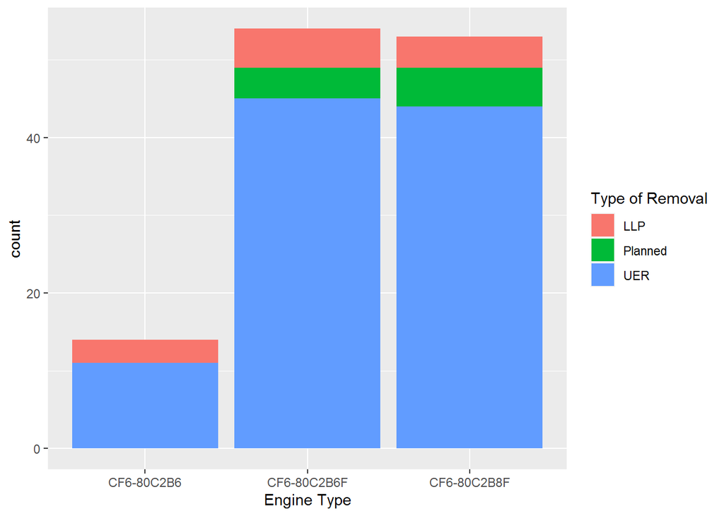

```r
ggplot(data=CF680) +
  geom_bar(mapping = aes(x=`Engine Type`, fill = `Type of Removal`))
```

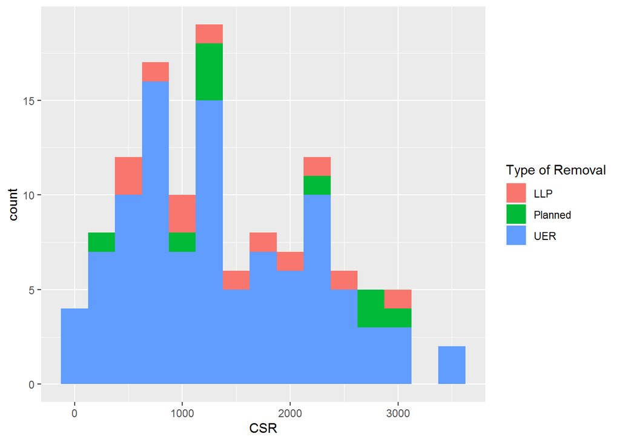

```r
ggplot(data=CF680, mapping = aes(x=CSR, fill = `Type of Removal`)) +
  geom_histogram(binwidth = 250)
```

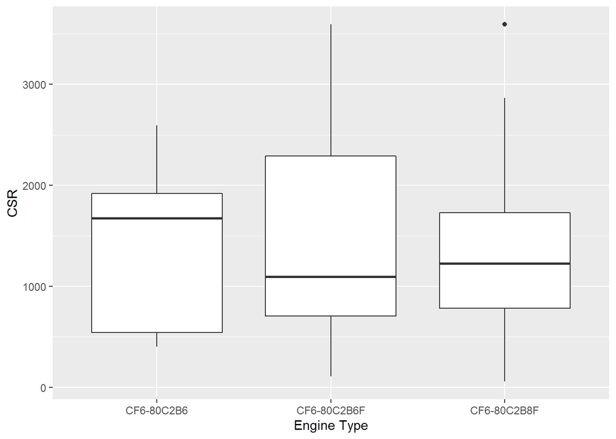

```r
ggplot(data = CF680, mapping = aes(x=`Engine Type`, y= CSR)) +
  geom_boxplot()
```

- Reduce data set to only removals in first 500 cycles

```r
CF680LT <- CF680 %>% filter(CSR <= 500)
```

- Down to 19 removals
- What are the causes for these removals?

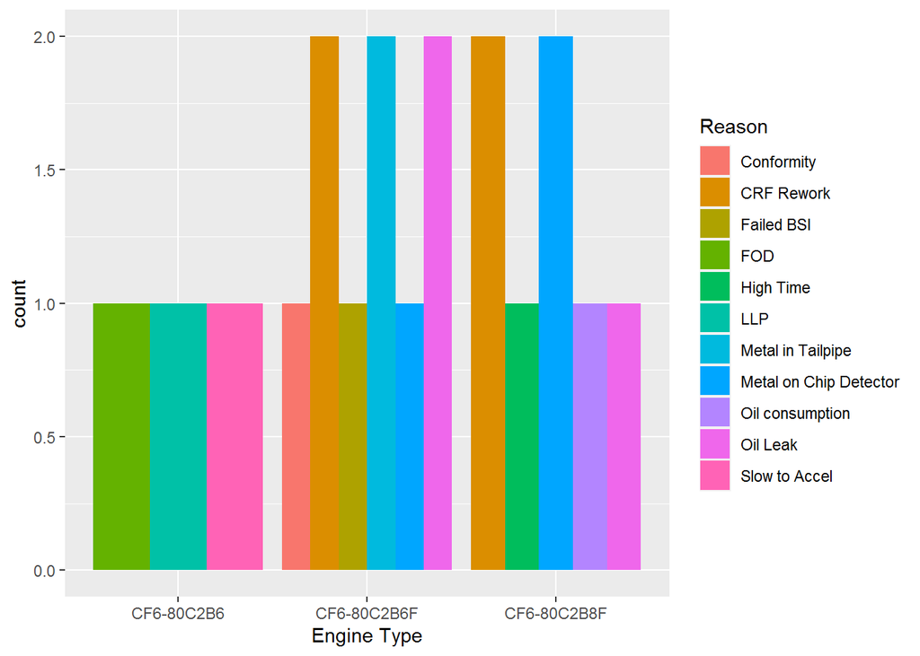

```r
ggplot(data = CF680LT, aes(x=`Engine Type`, fill = Reason)) +
  geom_bar(position = "dodge")
```